# R_A_W_F_Deck slides

## Exoplanet Analysis

#### Jared Pollack

#### January 20, 2020

[figure not shown]

## Expansion and colonization

- Running out of space and time (on Earth)
- over 4,000 exoplanets discovered, but only 55 are considered habitable
- So, how can we target an exoplanet for colonization, and find another home for humanity?

# Find an environment that resembles our own.

[figure not shown]

# Question 1 (Mass):

Is there a statistically significant difference between the average mass of exoplanets orbiting a host star smaller than the sun versus exoplanets with a host star that is as big as or larger than the sun?

# Yes.

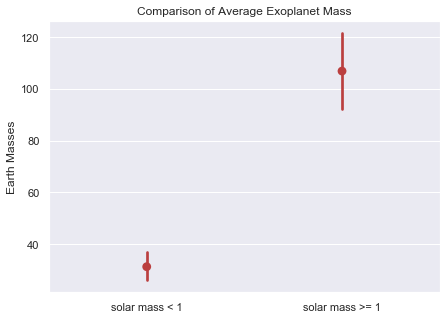

```
The difference in means at the 95% confidence interval (two-tail) is between 59.77656022563728 and 91.07816640543042.
```

```python
plt.figure(figsize = (7,5))
plt.title('Comparison of Average Exoplanet Mass')
plt.ylabel('Earth Masses', rotation=90)
em = sns.pointplot(data=[exo_l['earth_mass'], exo_g['earth_mass']], join=False, color="#bb3f3f")
em.set(xticklabels = ['solar mass < 1', 'solar mass >= 1'])
plt.show()
print(get_95_ci(exo_l['earth_mass'], exo_g['earth_mass']))
```

With 95% confidence, exoplanets with a host star greater than or equal to the sun have an average mass that is 60 - 91 earth masses greater than exoplanets that orbit a star smaller than the sun.

# Question 2 (Orbital Period):

Is there a statistically significant difference between the average orbital period of exoplanets with a host star smaller than the sun versus exoplanets orbiting a star that is as big as or larger than the sun?

# Yes.

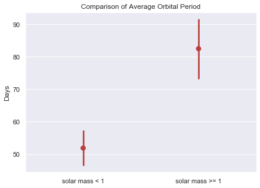

```
The difference in means at the 95% confidence interval (two-tail) is between 19.934477741466043 and 41.333482411344434.
```

```python
plt.figure(figsize = (7,5))
plt.title('Comparison of Average Orbital Period')
plt.ylabel('Days', rotation=90)
em = sns.pointplot(data=[exo_l['orbital_period'], exo_g['orbital_period']], join=False, color="#bb3f3f")
em.set(xticklabels = ['solar mass < 1', 'solar mass >= 1'])
plt.show()
print(get_95_ci(exo_l['orbital_period'], exo_g['orbital_period']))
```

With 95% confidence, exoplanets with a host star greater than or equal to the sun have an average orbital period that is 20 - 41 days longer than exoplanets that orbit a star smaller than the sun.

# Question 3 (Distance from our solar system):

Is there a statistically significant difference between the average distance of exoplanets with a host star smaller than the sun versus exoplanets orbiting a star that is as big as or larger than the sun?

# Yes.

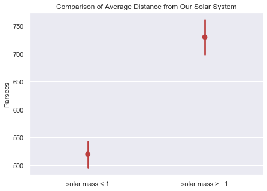

```
The difference in means at the 95% confidence interval (two-tail) is between 171.20835863577824 and 249.68278785973442.
```

```python
plt.figure(figsize = (7,5))
plt.title('Comparison of Average Distance from Our Solar System')
plt.ylabel('Parsecs', rotation=90)
em = sns.pointplot(data=[exo_l['dist_parsec'], exo_g['dist_parsec']], join=False, color="#bb3f3f")
em.set(xticklabels = ['solar mass < 1', 'solar mass >= 1'])
plt.show()
print(get_95_ci(exo_l['dist_parsec'], exo_g['dist_parsec']))
```

With 95% confidence, exoplanets with a host star greater than or equal to the sun are on average 171 - 250 parsecs farther away than exoplanets with a host star smaller than the sun.

# Discussion and Recommendations

For all 3 variables tested, the null was rejected.

- This suggests a strong relationship between the mass of a star and the properties of planets that orbit it.
- To be certain of this, we need to collect more data, which will take time.
- Also, there may exist a potential bias...

[figure not shown]

# Potential Bias: Exoplanet Discovery Methods

About 88% of exoplanets discovered have orbital periods less than 1 year.

Why might this be?

NASA discusses "5 Ways to Find a Planet" here: https://exoplanets.nasa.gov/alien-worlds/ways-to-find-a-planet/

Each of these methods appear to rely on some interaction between the exoplanet and it's host star. We believe that such interactions are easier to detect, and more often detectable for exoplanets that are closer to their host stars. Naturally, exoplanets closer to stars will have shorter orbital periods than more distant planets. We have contacted NASA to verify that this is the case.

# Questions?

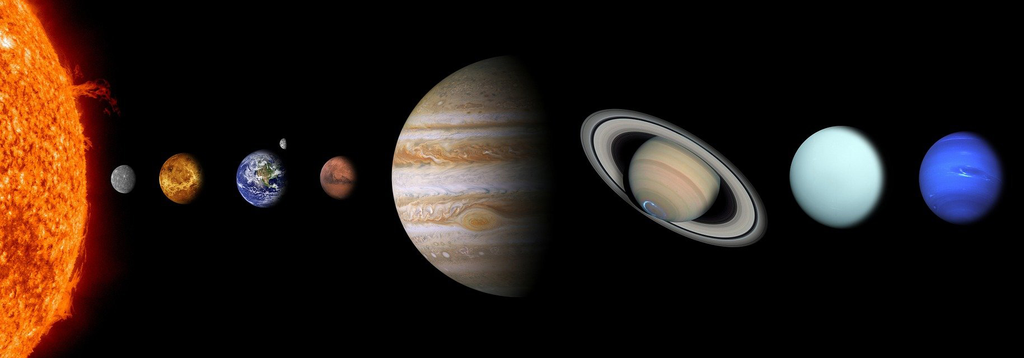